# Projeto de Capacidade Produtiva - Fase II

Allan B. Martins (CORED)

23 maio 2022

# Técnica utilizada para PCA análise de componentes principais acp ou pca -

Contextualização

A Metodologia ANÁLISE DE COMPONENTES PRINCIPAIS

A Análise de Componentes Principais ou PCA (Principal Component Analysis) é uma técnica de análise multivariada que pode ser usada para analisar inter-relações entre um grande número de variáveis e explicar essas variáveis em termos de suas dimensões inerentes (Componentes).

O objetivo é encontrar um meio de condensar a informação contida em várias variáveis originais em um conjunto menor de variáveis estatísticas (componentes) com uma perda mínima de informação.

O número de componentes principais se torna o número de variáveis consideradas na análise, mas geralmente as primeiras componentes são as mais importantes já que explicam a maior parte da variação total.

As componentes principais em geral são extraídas via matriz de covariância, mas também podem ser extraídas via matriz de correlação. baseia-se numa formulação matemática sofisticada.

Usaremos a função “factoextra” e “FactoMineR” desse pacote factoextra é um pacote R que facilita a extração e visualização da saída de análises exploratórias de dados multivariados, incluindo:

Análise de Componentes Principais (PCA), que é usada para resumir as informações contidas em dados multivariados contínuos (ou seja, quantitativos) reduzindo a dimensionalidade dos dados sem perder informações importantes.

# 1 Análises por variável estruturante

## 1.1 Variável GEO (Geográfico)

### 1.1.1 Etapa I - Estruturação do banco de dados

#### 1.1.1.1 Universo Estatístico

##### 1.1.1.1.1 Banco de dados variável GEO (Geográfico) = geo1 (qtd_mun_front x qtd_mun_tot) e geo2 (area_front x area_tot_ori)

```
## Rows: 26
## Columns: 3
## $ uf                               <chr> "AC", "AL", "AM", "AP", "BA", "CE", "~
## $ geo1_qtd_mun_front_x_qtd_mun_tot <dbl> 1.00000000, 0.00000000, 0.30645161, 0~
## $ geo2_area_front_x_area_tot_ori   <dbl> 0.88274116, 0.00000000, 0.23291862, 0~
```

#### 1.1.1.2 Tabela de dados GEO

| UF | geo1_qtd_mun_front_x_qtd_mun_tot | geo2_area_front_x_area_tot_ori |
| --- | --- | --- |
| AC | 1.0000000 | 0.8827412 |
| AL | 0.0000000 | 0.0000000 |
| AM | 0.3064516 | 0.2329186 |
| AP | 0.5000000 | 0.4933398 |
| BA | 0.0000000 | 0.0000000 |
| CE | 0.0000000 | 0.0000000 |
| ES | 0.0000000 | 0.0000000 |
| GO | 0.0000000 | 0.0000000 |
| MA | 0.0000000 | 0.0000000 |
| MG | 0.0000000 | 0.0000000 |
| MS | 0.5696203 | 0.4017503 |
| MT | 0.1985816 | 0.1230777 |
| PA | 0.0347222 | 0.0741424 |
| PB | 0.0000000 | 0.0000000 |
| PE | 0.0000000 | 0.0000000 |
| PI | 0.0000000 | 0.0000000 |
| PR | 0.3483709 | 0.2789671 |
| RJ | 0.0000000 | 0.0000000 |
| RN | 0.0000000 | 0.0000000 |
| RO | 0.5384615 | 0.5233265 |
| RR | 1.0000000 | 0.6889171 |
| RS | 0.3983903 | 0.5211077 |
| SC | 0.2813559 | 0.1529014 |
| SE | 0.0000000 | 0.0000000 |
| SP | 0.0000000 | 0.0000000 |
| TO | 0.0000000 | 0.0000000 |

### 1.1.2 Etapa II - Análise de Componentes Principais ou PCA (Principal Component Analysis)

```
##       eigenvalue variance.percent cumulative.variance.percent
## Dim.1 1.97341441        98.670721                    98.67072
## Dim.2 0.02658559         1.329279                   100.00000
```

#### 1.1.2.1 Gráficos de contribuição das variáveis

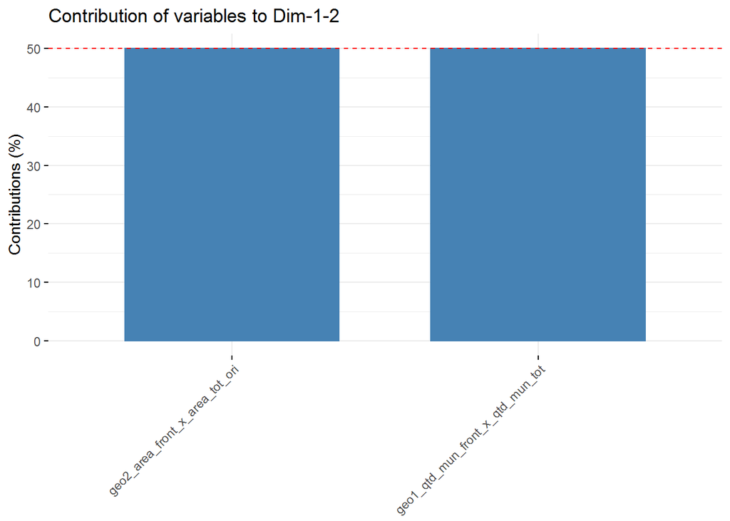

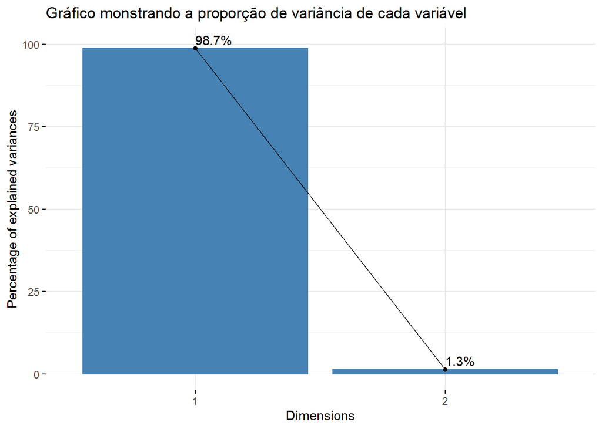

#### 1.1.2.2 Extrair os resultados das variáveis

```
## Principal Component Analysis Results for variables
##  ===================================================
##   Name       Description
## 1 "$coord"   "Coordinates for the variables"
## 2 "$cor"     "Correlations between variables and dimensions"
## 3 "$cos2"    "Cos2 for the variables"
## 4 "$contrib" "contributions of the variables"
```

```
##                                      Dim.1      Dim.2
## geo1_qtd_mun_front_x_qtd_mun_tot 0.9933314  0.1152944
## geo2_area_front_x_area_tot_ori   0.9933314 -0.1152944
```

```
##                                  Dim.1 Dim.2
## geo1_qtd_mun_front_x_qtd_mun_tot    50    50
## geo2_area_front_x_area_tot_ori      50    50
```

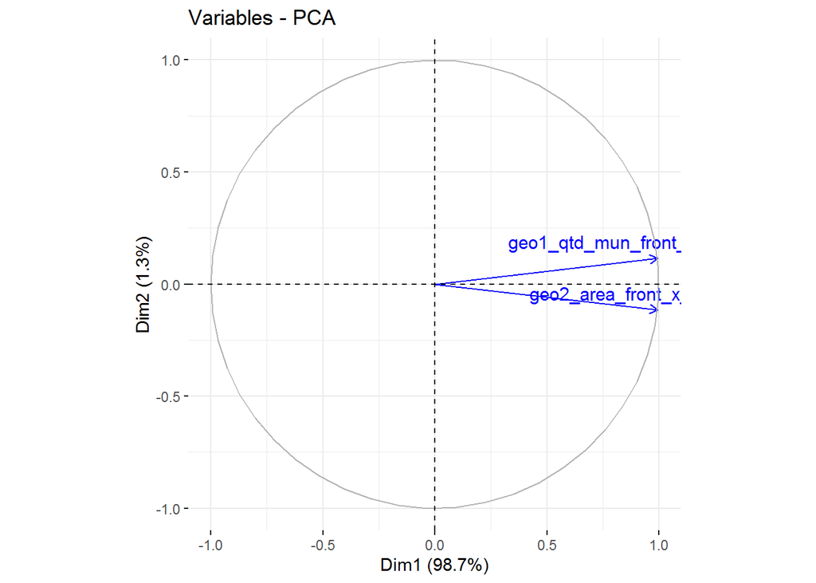

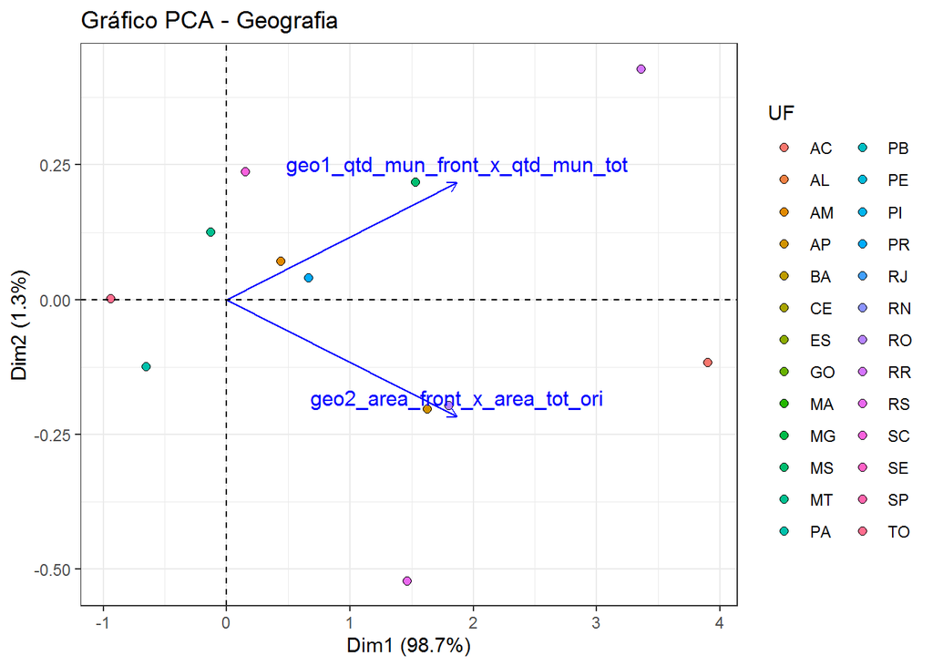

## 1.2 Variável SNB (Saneamento Básico)

### 1.2.1 Etapa I - Estruturação do banco de dados

#### 1.2.1.1 Universo Estatístico

##### 1.2.1.1.1 Banco de dados Variável Saneamento básico (SNB) = Esgoto (percent_esgoto_2017) e Água (percent_agua_2017)

```
## Rows: 26
## Columns: 3
## $ uf                  <chr> "AC", "AL", "AM", "AP", "BA", "CE", "ES", "GO", "M~
## $ percent_esgoto_2017 <dbl> 0.13636364, 0.32352941, 0.12903226, 0.37500000, 0.~
## $ percent_agua_2017   <dbl> 1.0000000, 0.9803922, 0.9677419, 1.0000000, 0.9976~
```

#### 1.2.1.2 Tabela de dados Saneamento básico

| UF | percent_esgoto_2017 | percent_agua_2017 |
| --- | --- | --- |
| AC | 0.1363636 | 1.0000000 |
| AL | 0.3235294 | 0.9803922 |
| AM | 0.1290323 | 0.9677419 |
| AP | 0.3750000 | 1.0000000 |
| BA | 0.6067146 | 0.9976019 |
| CE | 0.6304348 | 1.0000000 |
| ES | 0.9743590 | 1.0000000 |
| GO | 0.3441296 | 1.0000000 |
| MA | 0.0645161 | 0.9861751 |
| MG | 0.9284877 | 1.0000000 |
| MS | 0.6708861 | 1.0000000 |
| MT | 0.2836879 | 0.9787234 |
| PA | 0.1111111 | 0.9513889 |
| PB | 0.8071749 | 0.8923767 |
| PE | 0.8054054 | 0.9945946 |
| PI | 0.1116071 | 0.9821429 |
| PR | 0.5288221 | 1.0000000 |
| RJ | 0.9456522 | 1.0000000 |
| RN | 0.4550898 | 0.9820359 |
| RO | 0.1153846 | 0.9615385 |
| RR | 0.3333333 | 1.0000000 |
| RS | 0.3199195 | 0.9979879 |
| SC | 0.3966102 | 1.0000000 |
| SE | 0.4400000 | 1.0000000 |
| SP | 1.0000000 | 1.0000000 |
| TO | 0.1294964 | 1.0000000 |

### 1.2.2 Etapa II - Análise de Componentes Principais ou PCA (Principal Component Analysis)

```
##       eigenvalue variance.percent cumulative.variance.percent
## Dim.1  1.1104843         55.52422                    55.52422
## Dim.2  0.8895157         44.47578                   100.00000
```

#### 1.2.2.1 Gráficos de contribuição das variáveis

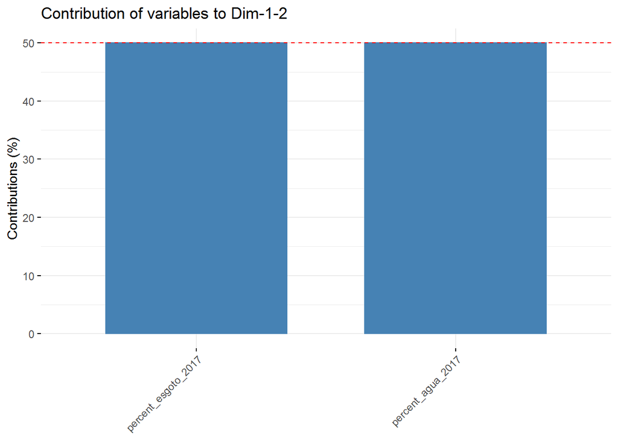

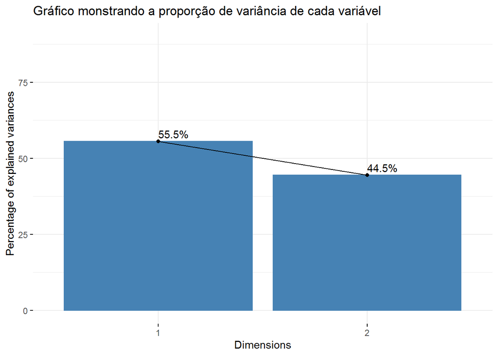

```
## Principal Component Analysis Results for variables
##  ===================================================
##   Name       Description
## 1 "$coord"   "Coordinates for the variables"
## 2 "$cor"     "Correlations between variables and dimensions"
## 3 "$cos2"    "Cos2 for the variables"
## 4 "$contrib" "contributions of the variables"
```

```
##                         Dim.1      Dim.2
## percent_esgoto_2017 0.7451457 -0.6669017
## percent_agua_2017   0.7451457  0.6669017
```

```
##                     Dim.1 Dim.2
## percent_esgoto_2017    50    50
## percent_agua_2017      50    50
```

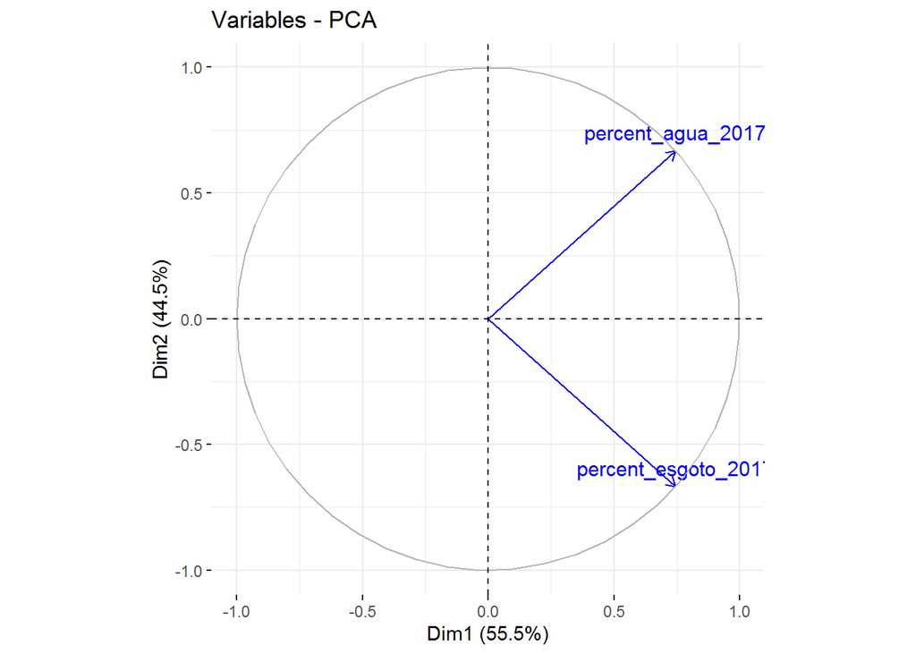

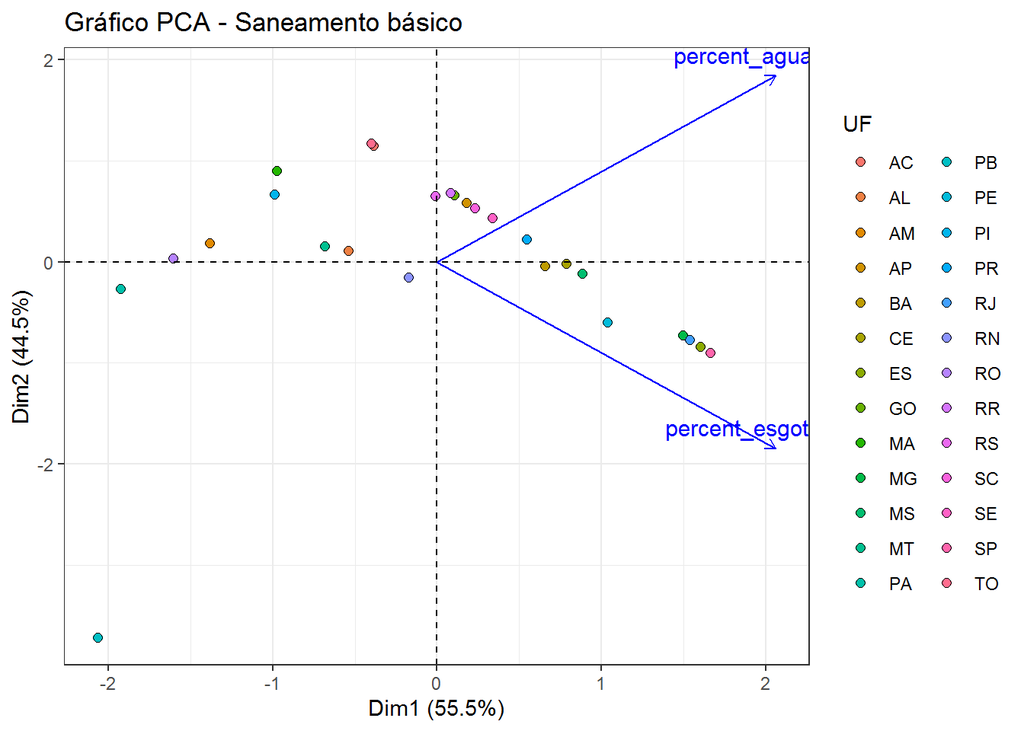

## 1.3 Variável TELECOM (Telecomunicação)

### 1.3.1 Etapa I - Estruturação do banco de dados

#### 1.3.1.1 Universo Estatístico

##### 1.3.1.1.1 Banco de dados variável TELECOM (Telecomunicação) = telecom1 (qtd_ag_correios x total_população) e telecom2 (qtd_minicipios_fibra x tota_municipios)

```
## Rows: 26
## Columns: 3
## $ uf                        <chr> "AC", "AL", "AM", "AP", "BA", "CE", "ES", "G~
## $ ag_correios_por_pop_total <dbl> 0.03046309, 0.03522506, 0.02147097, 0.031346~
## $ percent_fribra_2021       <dbl> 0.22727273, 0.13725490, 0.14516129, 0.312500~
```

#### 1.3.1.2 Tabela de dados telecom

| UF | ag_correios_por_pop_total | percent_fribra_2021 |
| --- | --- | --- |
| AC | 0.0304631 | 0.2272727 |
| AL | 0.0352251 | 0.1372549 |
| AM | 0.0214710 | 0.1451613 |
| AP | 0.0313461 | 0.3125000 |
| BA | 0.0317228 | 0.2805755 |
| CE | 0.0245343 | 0.2173913 |
| ES | 0.0303474 | 0.3076923 |
| GO | 0.0367207 | 0.1700405 |
| MA | 0.0329577 | 0.2442396 |
| MG | 0.0485458 | 0.1664713 |
| MS | 0.0369560 | 0.3797468 |
| MT | 0.0446305 | 0.2978723 |
| PA | 0.0208757 | 0.5138889 |
| PB | 0.0529423 | 0.0896861 |
| PE | 0.0235310 | 0.1405405 |
| PI | 0.0606831 | 0.1071429 |
| PR | 0.0408542 | 0.1679198 |
| RJ | 0.0160059 | 0.6413043 |
| RN | 0.0524119 | 0.0658683 |
| RO | 0.0359939 | 0.1538462 |
| RR | 0.0358066 | 0.1333333 |
| RS | 0.0522250 | 0.2555332 |
| SC | 0.0435165 | 0.2067797 |
| SE | 0.0390188 | 0.4533333 |
| SP | 0.0238311 | 0.8589147 |
| TO | 0.0917384 | 0.1151079 |

### 1.3.2 Etapa II - Análise de Componentes Principais ou PCA (Principal Component Analysis)

```
##       eigenvalue variance.percent cumulative.variance.percent
## Dim.1  1.4812778         74.06389                    74.06389
## Dim.2  0.5187222         25.93611                   100.00000
```

#### 1.3.2.1 Gráficos de contribuição das variáveis

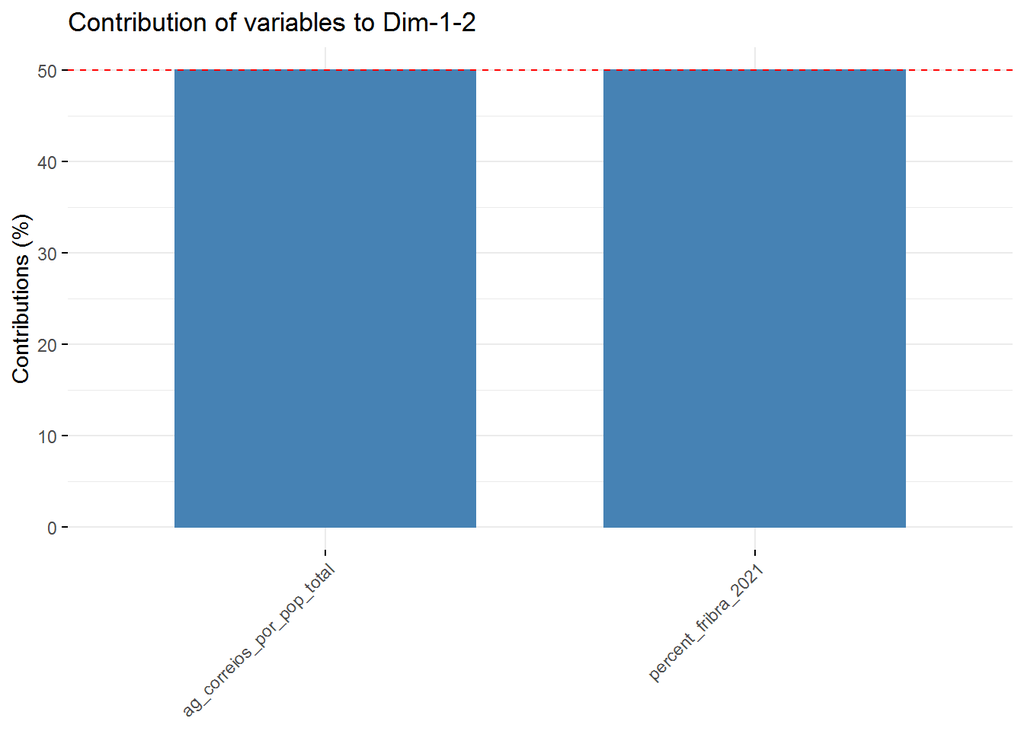

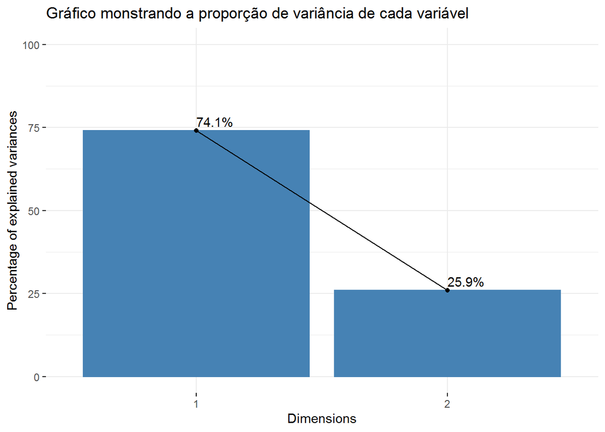

#### 1.3.2.2 Extrair os resultados das variáveis

```
## Principal Component Analysis Results for variables
##  ===================================================
##   Name       Description
## 1 "$coord"   "Coordinates for the variables"
## 2 "$cor"     "Correlations between variables and dimensions"
## 3 "$cos2"    "Cos2 for the variables"
## 4 "$contrib" "contributions of the variables"
```

```
##                                Dim.1     Dim.2
## ag_correios_por_pop_total  0.8606038 0.5092751
## percent_fribra_2021       -0.8606038 0.5092751
```

```
##                           Dim.1 Dim.2
## ag_correios_por_pop_total    50    50
## percent_fribra_2021          50    50
```

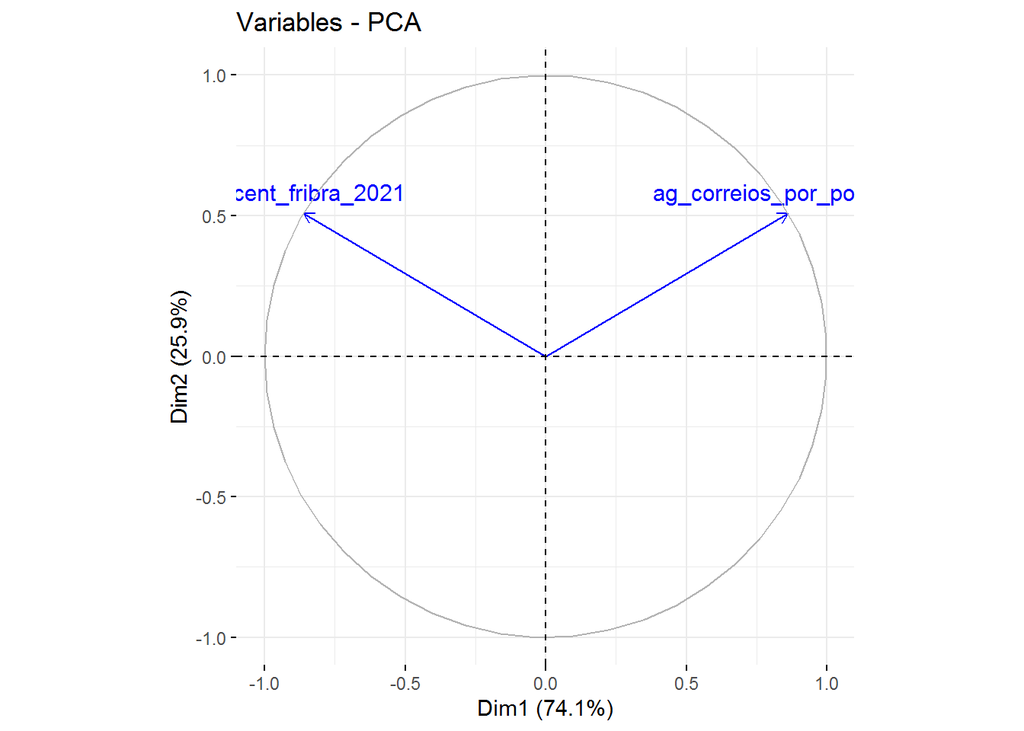

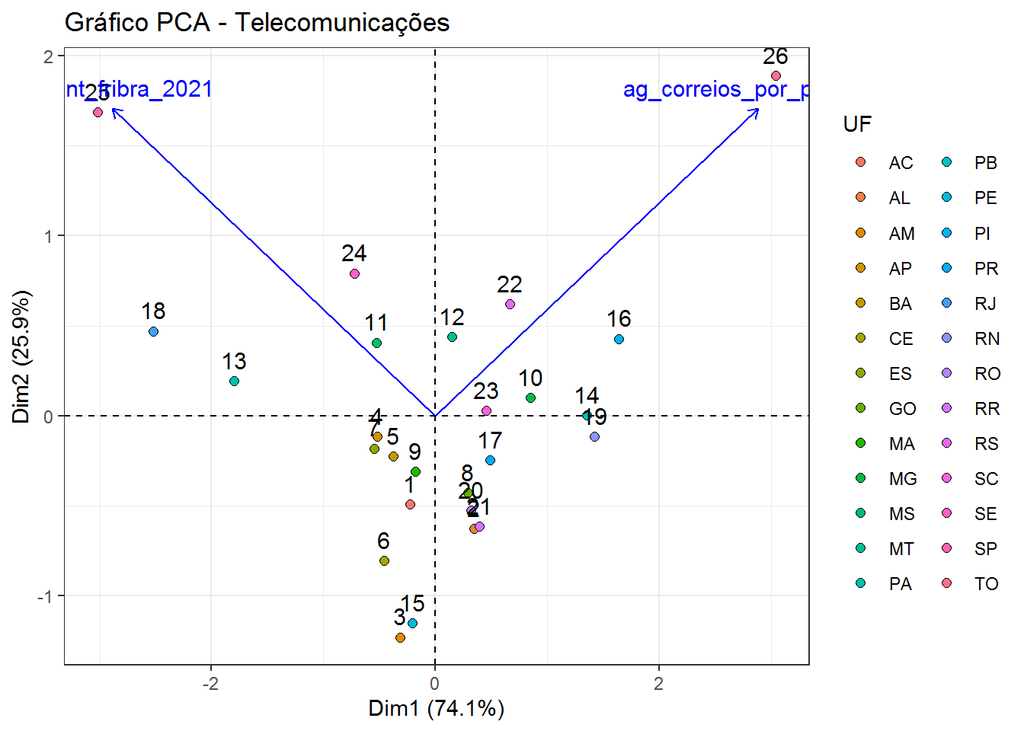

# 2 Diversos

## 2.2 Material de Apoio

- Multivariate Data Analyses:[]https://rpkgs.datanovia.com/factoextra/index.html)
- A Metodologia PCA: []https://operdata.com.br/blog/analise-de-componentes-principais/
- PCA análise de componentes principais acp ou pca:[]https://youtu.be/hmp9KIPb5Ig
- PCA dúvidas e sugestões sobre análise de componentes principais:[]https://youtu.be/ATXoqEtNtdg
- PLAYLIST - R na Pesquisa Contábil (Parte 1 ao 20):[]https://youtube.com/playlist?list=PLF3Sjk1EY74ZcUWHE6ZDPHFRu9zp_20gD
- PLAYLIST - Criando gráficos no R com o ggplot2 (Parte 1 ao 2): [Fernanda Peres]https://youtu.be/DYsPRa3vpf0
- PLAYLIST - R Markdown: Gerando relatórios usando o R (Parte 1 ao 5): [Fernanda Peres]https://youtu.be/obxa5VH4WvY
- Minicurso R - UFPR: [UFPR]https://youtu.be/obxa5VH4WvY
- R Markdown: The Definitive Guide: [Yihui Xie, J. J. Allaire, Garrett Grolemund]https://bookdown.org/yihui/rmarkdown/